# Tourism Project / Yeoman Yoon

## Bagging:

### Decision Tree

```python
dTree = DecisionTreeClassifier(criterion='gini',random_state=1)
dTree.fit(x_train, y_train)
```

```
DecisionTreeClassifier(random_state=1)
```

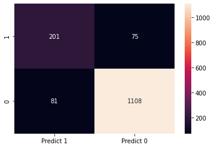

```python
make_cm(dTree,y_test)
```

```python
dTree_score = get_score_acc_rec_prec(dTree)
print_score(dTree_score,'all')
```

```
Accuracy on training set :  1.0
Accuracy on test set :  0.8935153583617748
Recall on training set :  1.0
Recall on test set :  0.7282608695652174
Precision on training set :  1.0
Precision on test set :  0.7127659574468085
```

### Random Forest

```python
rForest = RandomForestClassifier(random_state=1)
rForest.fit(x_train,y_train)
```

```
RandomForestClassifier(random_state=1)
```

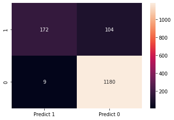

```python
make_cm(rForest,y_test)
```

```python
rForest_score = get_score_acc_rec_prec(rForest)
print_score(rForest_score,'all')
```

```
Accuracy on training set :  1.0
Accuracy on test set :  0.9228668941979522
Recall on training set :  1.0
Recall on test set :  0.6231884057971014
Precision on training set :  1.0
Precision on test set :  0.9502762430939227
```

### Random Forest with Class_Weight

```python
rForestPlus = RandomForestClassifier(random_state=1, class_weight={0:0.25,1:0.75})
rForestPlus.fit(x_train,y_train)
```

```
RandomForestClassifier(class_weight={0: 0.25, 1: 0.75}, random_state=1)
```

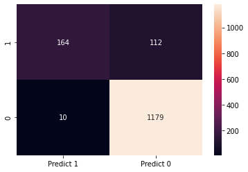

```python
make_cm(rForestPlus,y_test)
```

```python
rForestPlus_score = get_score_acc_rec_prec(rForestPlus)
print_score(rForestPlus_score,'all')
```

```
Accuracy on training set :  1.0
Accuracy on test set :  0.9167235494880546
Recall on training set :  1.0
Recall on test set :  0.5942028985507246
Precision on training set :  1.0
Precision on test set :  0.9425287356321839
```

The Class_weight did not help the model

### Bagging Classifier

```python
bClassifier = BaggingClassifier(random_state=1)
bClassifier.fit(x_train,y_train)
```

```
BaggingClassifier(random_state=1)
```

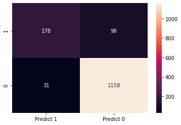

```python
make_cm(bClassifier,y_test)
```

```python
bClassifier_score = get_score_acc_rec_prec(bClassifier)
print_score(bClassifier_score,'all')
```

```
Accuracy on training set :  0.9926836406204272
Accuracy on test set :  0.9119453924914676
Recall on training set :  0.9611801242236024
Recall on test set :  0.644927536231884
Precision on training set :  1.0
Precision on test set :  0.8516746411483254
```

### Bagging Classifier with Class_Weight (Didn't help)

```python
bClassifierPlus = BaggingClassifier(base_estimator=DecisionTreeClassifier(criterion='gini',class_weight={0:0.25,1:0.75},random_state=1),random_state=1)
bClassifierPlus.fit(x_train,y_train)
```

```
BaggingClassifier(base_estimator=DecisionTreeClassifier(class_weight={0: 0.25,
                                                                      1: 0.75},
                                                        random_state=1),
                  random_state=1)
```

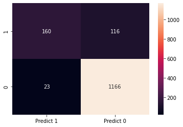

```python
make_cm(bClassifierPlus,y_test)
```

```python
bClassifierPlus_score = get_score_acc_rec_prec(bClassifierPlus)
print_score(bClassifierPlus_score,'all')
```

```
Accuracy on training set :  0.9906350599941469
Accuracy on test set :  0.9051194539249147
Recall on training set :  0.9565217391304348
Recall on test set :  0.5797101449275363
Precision on training set :  0.9935483870967742
Precision on test set :  0.8743169398907104
```

The Class_weight helped increasing precision but not recall (made it worse)

## Improving Bagging Models

### Decision Tree

```python
dTreeOptimum = DecisionTreeClassifier(class_weight={0:0.25,1:0.75},random_state=1)

# parameters to find optimum
parameters_dTree = {'max_depth': np.arange(2,30),
              'min_samples_leaf': [1, 2, 5, 7, 9],
              'max_leaf_nodes' : [2, 3, 5, 10, 14],
              'min_impurity_decrease': [0.0001,0.001,0.01,0.1]
             }

scorer = metrics.make_scorer(metrics.recall_score)

# Run the grid search
grid_dTree = GridSearchCV(dTreeOptimum, parameters_dTree, scoring=scorer, cv = 5)
grid_dTree = grid_dTree.fit(x_train, y_train)

# Set the best extimator.
dTreeOptimum = grid_dTree.best_estimator_

# Fit the best algorithm to the data.
dTreeOptimum.fit(x_train, y_train)
```

```
DecisionTreeClassifier(class_weight={0: 0.25, 1: 0.75}, max_depth=6,
                       max_leaf_nodes=14, min_impurity_decrease=0.0001,
                       random_state=1)
```

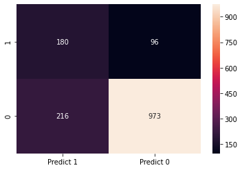

```python
make_cm(dTreeOptimum,y_test)
```

```python
dTreeOptimum_score = get_score_acc_rec_prec(dTreeOptimum)
print_score(dTreeOptimum_score,'all')
```

```
Accuracy on training set :  0.800702370500439
Accuracy on test set :  0.7870307167235495
Recall on training set :  0.6413043478260869
Recall on test set :  0.6521739130434783
Precision on training set :  0.47856315179606024
Precision on test set :  0.45454545454545453
```

Overfitting is resolved, but the score is worse

### Bagging Classifier

```python
dTreeImp = DecisionTreeClassifier(class_weight={0:0.25,1:0.75},random_state=1)
parameters_bagging= {'base_estimator':[dTreeImp],
              'n_estimators':[5,8,15,50,100],
              'max_features': [0.7,0.8,0.9,1]
             }

grid_bClass = GridSearchCV(BaggingClassifier(random_state=1,bootstrap=True),
                           param_grid=parameters_bagging, scoring = scorer, cv = 5)
grid_bClass.fit(x_train, y_train)

bClassifierOptimum  = grid_bClass.best_estimator_
bClassifierOptimum.fit(x_train,y_train)
```

```
BaggingClassifier(base_estimator=DecisionTreeClassifier(class_weight={0: 0.25,
                                                                      1: 0.75},
                                                        random_state=1),
                  max_features=0.9, n_estimators=15, random_state=1)
```

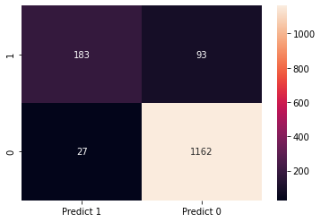

```python
make_cm(bClassifierOptimum,y_test)
```

```python
bClassifierOptimum_score = get_score_acc_rec_prec(bClassifierOptimum)
print_score(bClassifierOptimum_score,'all')
```

```
Accuracy on training set :  0.9964881474978051
Accuracy on test set :  0.9180887372013652
Recall on training set :  0.984472049689441
Recall on test set :  0.6630434782608695
Precision on training set :  0.9968553459119497
Precision on test set :  0.8714285714285714
```

Still suspect for Overfitting. Recall is not satisfying

### Random Forest

```python
rForestOptimum = RandomForestClassifier(random_state=1)

# parameters to find optimum
parameters_rForest = {
        "n_estimators": [501], # more tree is mostly better.
        "min_samples_leaf": np.arange(1,6),
        "max_features": [0.7,0.9,'log2','auto']
}

grid_rForest = GridSearchCV(rForestOptimum, parameters_rForest, scoring='recall',cv=5)
grid_rForest = grid_rForest.fit(x_train, y_train)

rForestOptimum = grid_rForest.best_estimator_
rForestOptimum.fit(x_train, y_train)
```

```
RandomForestClassifier(max_features=0.7, n_estimators=501, random_state=1)
```

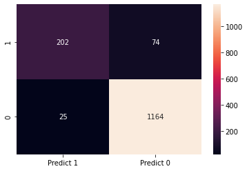

```python
make_cm(rForestOptimum,y_test)
```

```python
rForestOptimum_score = get_score_acc_rec_prec(rForestOptimum)
print_score(rForestOptimum_score,'all')
```

```
Accuracy on training set :  1.0
Accuracy on test set :  0.9324232081911262
Recall on training set :  1.0
Recall on test set :  0.7318840579710145
Precision on training set :  1.0
Precision on test set :  0.8898678414096917
```

Overfitting is present, but the accuracy along with recall increased significantly.

## Compare Bagging Models

```python
# defining list of models
modelList = [dTree,dTreeOptimum,
          bClassifier,bClassifierPlus,bClassifierOptimum,
          rForest,rForestPlus,rForestOptimum]

# Empty lists to add results
acc_train = []
acc_test = []
rec_train = []
rec_test = []
prec_train = []
prec_test = []

# loop score
for model in modelList:
    score = get_score_acc_rec_prec(model)
    acc_train.append(score[0])
    acc_test.append(score[1])
    rec_train.append(score[2])
    rec_test.append(score[3])
    prec_train.append(score[4])
    prec_test.append(score[5])
```

```python
compare_frame = pd.DataFrame({'Model':['Decision Tree','Optimum Decision Tree','Bagging Classifier',
                                          'Weighted Bagging Classifier','Optimum Bagging Classifier',
                                          'Random Forest','Weighted Random Forest','Optimum Random Forest'],
                                          'TrainAccuracy': acc_train,
                                          'TestAccuracy': acc_test,
                                          'TrainRecall': rec_train,
                                          'TestRecall': rec_test,
                                          'TrainPrecision': prec_train,
                                          'TestPrecision': prec_test})
compare_frame
```

|  | Model | TrainAccuracy | TestAccuracy | TrainRecall | TestRecall | TrainPrecision | TestPrecision |
| --- | --- | --- | --- | --- | --- | --- | --- |
| 0 | Decision Tree | 1.000000 | 0.893515 | 1.000000 | 0.728261 | 1.000000 | 0.712766 |
| 1 | Optimum Decision Tree | 0.800702 | 0.787031 | 0.641304 | 0.652174 | 0.478563 | 0.454545 |
| 2 | Bagging Classifier | 0.992684 | 0.911945 | 0.961180 | 0.644928 | 1.000000 | 0.851675 |
| 3 | Weighted Bagging Classifier | 0.990635 | 0.905119 | 0.956522 | 0.579710 | 0.993548 | 0.874317 |
| 4 | Optimum Bagging Classifier | 0.996488 | 0.918089 | 0.984472 | 0.663043 | 0.996855 | 0.871429 |
| 5 | Random Forest | 1.000000 | 0.922867 | 1.000000 | 0.623188 | 1.000000 | 0.950276 |
| 6 | Weighted Random Forest | 1.000000 | 0.916724 | 1.000000 | 0.594203 | 1.000000 | 0.942529 |
| 7 | Optimum Random Forest | 1.000000 | 0.932423 | 1.000000 | 0.731884 | 1.000000 | 0.889868 |

### Bagging Conclusion:

Among 8 Bagging classifiers, Optimum Random Forest Classifier has the best Accuracy and Recall.

## Boosting:

### AdaBoost Classifier

```python
adaBoost = AdaBoostClassifier(random_state=1)
adaBoost.fit(x_train,y_train)
```

```
AdaBoostClassifier(random_state=1)
```

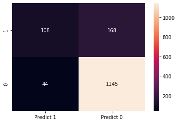

```python
make_cm(adaBoost,y_test)
```

```python
adaBoost_score = get_score_acc_rec_prec(adaBoost)
print_score(adaBoost_score,'all')
```

```
Accuracy on training set :  0.8484050336552531
Accuracy on test set :  0.8552901023890785
Recall on training set :  0.3136645962732919
Recall on test set :  0.391304347826087
Precision on training set :  0.7266187050359713
Precision on test set :  0.7105263157894737
```

No overfitting detected but poor recall.

### Gradient Boosting Classifier

```python
gBoost = GradientBoostingClassifier(random_state=1)
gBoost.fit(x_train,y_train)
```

```
GradientBoostingClassifier(random_state=1)
```

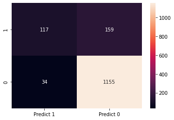

```python
make_cm(gBoost,y_test)
```

```python
gBoost_score = get_score_acc_rec_prec(gBoost)
print_score(gBoost_score,'all')
```

```
Accuracy on training set :  0.8884986830553117
Accuracy on test set :  0.868259385665529
Recall on training set :  0.4798136645962733
Recall on test set :  0.42391304347826086
Precision on training set :  0.8704225352112676
Precision on test set :  0.7748344370860927
```

No overfitting detected but poor recall.

### XGBoost Classifier

```python
xgBoost = XGBClassifier(random_state=1, eval_metric='logloss')
xgBoost.fit(x_train,y_train)
```

```
XGBClassifier(base_score=0.5, booster='gbtree', colsample_bylevel=1,
              colsample_bynode=1, colsample_bytree=1, eval_metric='logloss',
              gamma=0, gpu_id=-1, importance_type='gain',
              interaction_constraints='', learning_rate=0.300000012,
              max_delta_step=0, max_depth=6, min_child_weight=1, missing=nan,
              monotone_constraints='()', n_estimators=100, n_jobs=8,
              num_parallel_tree=1, random_state=1, reg_alpha=0, reg_lambda=1,
              scale_pos_weight=1, subsample=1, tree_method='exact',
              validate_parameters=1, verbosity=None)
```

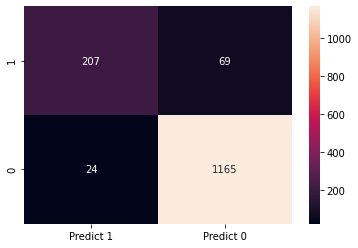

```python
make_cm(xgBoost,y_test)
```

```python
xgBoost_score = get_score_acc_rec_prec(xgBoost)
print_score(xgBoost_score,'all')
```

```
Accuracy on training set :  0.9997073456248171
Accuracy on test set :  0.936518771331058
Recall on training set :  0.9984472049689441
Recall on test set :  0.75
Precision on training set :  1.0
Precision on test set :  0.8961038961038961
```

Overfitting is present, but pretty good recall.

## Improving Models

### AdaBoost

```python
adaBoostOptimum = AdaBoostClassifier(random_state=1)

parameters_adaBoost = {
    "base_estimator":[DecisionTreeClassifier(max_depth=1),DecisionTreeClassifier(max_depth=2),
                      DecisionTreeClassifier(max_depth=3)],
    "n_estimators": np.arange(10,110,10),
    "learning_rate":np.arange(0.1,2,0.2)
}

grid_adaBoost = GridSearchCV(adaBoostOptimum, parameters_adaBoost, scoring="recall",cv=5)
grid_adaBoost = grid_adaBoost.fit(x_train, y_train)

adaBoostOptimum = grid_adaBoost.best_estimator_
adaBoostOptimum.fit(x_train, y_train)
```

```
AdaBoostClassifier(base_estimator=DecisionTreeClassifier(max_depth=3),
                   learning_rate=1.7000000000000004, n_estimators=90,
                   random_state=1)
```

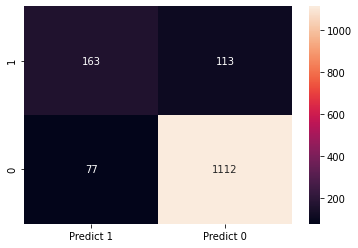

```python
make_cm(adaBoostOptimum,y_test)
```

```python
adaBoostOptimum_score = get_score_acc_rec_prec(adaBoostOptimum)
print_score(adaBoostOptimum_score,'all')
```

```
Accuracy on training set :  0.9760023412350015
Accuracy on test set :  0.8703071672354948
Recall on training set :  0.9130434782608695
Recall on test set :  0.5905797101449275
Precision on training set :  0.9576547231270358
Precision on test set :  0.6791666666666667
```

A lot better than not optimized adaBoost, but still not satisfying recall.

### Gradient

```python
gBoostOptimum = GradientBoostingClassifier(init=AdaBoostClassifier(random_state=1),random_state=1)

parameters_gBoost = {
    "n_estimators": [100,180,250],
    "subsample":[0.8,0.9,1],
    "max_features":[0.7,0.9,1]
}

grid_gBoost = GridSearchCV(gBoostOptimum, parameters_gBoost, scoring="recall",cv=5)
grid_gBoost = grid_gBoost.fit(x_train, y_train)

gBoostOptimum = grid_gBoost.best_estimator_
gBoostOptimum.fit(x_train, y_train)
```

```
GradientBoostingClassifier(init=AdaBoostClassifier(random_state=1),
                           max_features=0.9, n_estimators=250, random_state=1,
                           subsample=0.8)
```

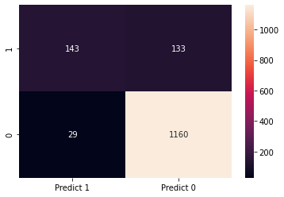

```python
make_cm(gBoostOptimum,y_test)
```

```python
gBoostOptimum_score = get_score_acc_rec_prec(gBoostOptimum)
print_score(gBoostOptimum_score,'all')
```

```
Accuracy on training set :  0.9209833187006146
Accuracy on test set :  0.889419795221843
Recall on training set :  0.6211180124223602
Recall on test set :  0.5181159420289855
Precision on training set :  0.9389671361502347
Precision on test set :  0.8313953488372093
```

A lot better than not optimized gradientBoost, but still not satisfying recall.

### XGBoost Classifier

```python
xgBoostOptimum= XGBClassifier(random_state=1, eval_metric='logloss')

parameters_xgBoost = {
    "n_estimators": [10,30,50],
    "scale_pos_weight":[1,2,5],
    "subsample":[0.7,0.9,1],
    "learning_rate":[0.05, 0.1,0.2],
    "colsample_bytree":[0.7,0.9,1],
    "colsample_bylevel":[0.5,0.7,1]
}

grid_xgBoosting = GridSearchCV(xgBoostOptimum, parameters_xgBoost,scoring="recall",cv=5)
grid_xgBoosting = grid_xgBoosting.fit(x_train, y_train)

xgBoostOptimum = grid_xgBoosting.best_estimator_
xgBoostOptimum.fit(x_train, y_train)
```

```
XGBClassifier(base_score=0.5, booster='gbtree', colsample_bylevel=0.5,
              colsample_bynode=1, colsample_bytree=0.7, eval_metric='logloss',
              gamma=0, gpu_id=-1, importance_type='gain',
              interaction_constraints='', learning_rate=0.1, max_delta_step=0,
              max_depth=6, min_child_weight=1, missing=nan,
              monotone_constraints='()', n_estimators=50, n_jobs=8,
              num_parallel_tree=1, random_state=1, reg_alpha=0, reg_lambda=1,
              scale_pos_weight=5, subsample=1, tree_method='exact',
              validate_parameters=1, verbosity=None)
```

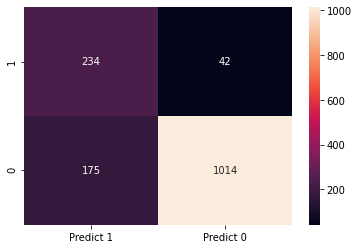

```python
make_cm(xgBoostOptimum,y_test)
```

```python
xgBoostOptimum_score = get_score_acc_rec_prec(xgBoostOptimum)
print_score(xgBoostOptimum_score,'all')
```

```
Accuracy on training set :  0.9201053555750659
Accuracy on test set :  0.851877133105802
Recall on training set :  0.9503105590062112
Recall on test set :  0.8478260869565217
Precision on training set :  0.7174677608440797
Precision on test set :  0.5721271393643031
```

Much better than not optimized xgBoost. Decent recall. need to check if better model can be found.

## Stacking Classifier

```python
estimators = [('Random Forest',rForestOptimum), ('Gradient Boosting',gBoostOptimum), ('Decision Tree',dTreeOptimum)]
final_estimator = xgBoostOptimum

stacking = StackingClassifier(estimators=estimators,final_estimator=final_estimator)
stacking.fit(x_train,y_train)
```

```
StackingClassifier(estimators=[('Random Forest',
                                RandomForestClassifier(max_features=0.7,
                                                       n_estimators=501,
                                                       random_state=1)),
                               ('Gradient Boosting',
                                GradientBoostingClassifier(init=AdaBoostClassifier(random_state=1),
                                                           max_features=0.9,
                                                           n_estimators=250,
                                                           random_state=1,
                                                           subsample=0.8)),
                               ('Decision Tree',
                                DecisionTreeClassifier(class_weight={0: 0.25,
                                                                     1: 0.75},
                                                       max_depth...
                                                 eval_metric='logloss', gamma=0,
                                                 gpu_id=-1,
                                                 importance_type='gain',
                                                 interaction_constraints='',
                                                 learning_rate=0.1,
                                                 max_delta_step=0, max_depth=6,
                                                 min_child_weight=1,
                                                 missing=nan,
                                                 monotone_constraints='()',
                                                 n_estimators=50, n_jobs=8,
                                                 num_parallel_tree=1,
                                                 random_state=1, reg_alpha=0,
                                                 reg_lambda=1,
                                                 scale_pos_weight=5,
                                                 subsample=1,
                                                 tree_method='exact',
                                                 validate_parameters=1,
                                                 verbosity=None))
```

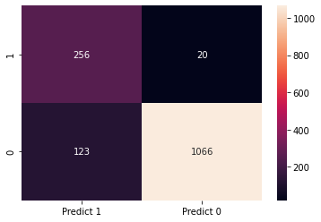

```python
make_cm(stacking,y_test)
```

```python
stacking_score = get_score_acc_rec_prec(stacking)
print_score(stacking_score,'all')
```

```
Accuracy on training set :  0.9961954931226222
Accuracy on test set :  0.9023890784982935
Recall on training set :  1.0
Recall on test set :  0.927536231884058
Precision on training set :  0.9802130898021308
Precision on test set :  0.6754617414248021
```

## Compare All Models

```python
#list of all the models
modelList = [dTree,dTreeOptimum,bClassifier,bClassifierPlus,bClassifierOptimum,rForest,rForestPlus,rForestOptimum,
             adaBoost,gBoost,xgBoost,adaBoostOptimum,gBoostOptimum,xgBoostOptimum,stacking]

acc_train = []
acc_test = []
rec_train = []
rec_test = []
prec_train = []
prec_test = []

for model in modelList:
    score = get_score_acc_rec_prec(model)
    acc_train.append(score[0])
    acc_test.append(score[1])
    rec_train.append(score[2])
    rec_test.append(score[3])
    prec_train.append(score[4])
    prec_test.append(score[5])
```

```python
comparison_frame = pd.DataFrame({'Model':['Decision Tree','Optimum Decision Tree','Bagging Classifier',
                                          'Weighted Bagging Classifier','Optimum Bagging Classifier',
                                          'Random Forest','Weighted Random Forest','Optimum Random Forest',
                                          'AdaBoost Classifier','Gradient Boosting Classifier','XGBoost Classifier',
                                          'Optimum AdaBoost Classifier','Optimum Gradient Boosting Classifier',
                                          'Optimum XGBoost Classifier','Stacking Classifier'],
                                          'TrainAccuracy': acc_train,'TestAccuracy': acc_test,
                                          'TrainRecall':rec_train,'TestRecall':rec_test,
                                          'TrainPrecision':prec_train,'TestPrecision':prec_test})


comparison_frame
```

|  | Model | TrainAccuracy | TestAccuracy | TrainRecall | TestRecall | TrainPrecision | TestPrecision |
| --- | --- | --- | --- | --- | --- | --- | --- |
| 0 | Decision Tree | 1.000000 | 0.893515 | 1.000000 | 0.728261 | 1.000000 | 0.712766 |
| 1 | Optimum Decision Tree | 0.800702 | 0.787031 | 0.641304 | 0.652174 | 0.478563 | 0.454545 |
| 2 | Bagging Classifier | 0.992684 | 0.911945 | 0.961180 | 0.644928 | 1.000000 | 0.851675 |
| 3 | Weighted Bagging Classifier | 0.990635 | 0.905119 | 0.956522 | 0.579710 | 0.993548 | 0.874317 |
| 4 | Optimum Bagging Classifier | 0.996488 | 0.918089 | 0.984472 | 0.663043 | 0.996855 | 0.871429 |
| 5 | Random Forest | 1.000000 | 0.922867 | 1.000000 | 0.623188 | 1.000000 | 0.950276 |
| 6 | Weighted Random Forest | 1.000000 | 0.916724 | 1.000000 | 0.594203 | 1.000000 | 0.942529 |
| 7 | Optimum Random Forest | 1.000000 | 0.932423 | 1.000000 | 0.731884 | 1.000000 | 0.889868 |
| 8 | AdaBoost Classifier | 0.848405 | 0.855290 | 0.313665 | 0.391304 | 0.726619 | 0.710526 |
| 9 | Gradient Boosting Classifier | 0.888499 | 0.868259 | 0.479814 | 0.423913 | 0.870423 | 0.774834 |
| 10 | XGBoost Classifier | 0.999707 | 0.936519 | 0.998447 | 0.750000 | 1.000000 | 0.896104 |
| 11 | Optimum AdaBoost Classifier | 0.976002 | 0.870307 | 0.913043 | 0.590580 | 0.957655 | 0.679167 |
| 12 | Optimum Gradient Boosting Classifier | 0.920983 | 0.889420 | 0.621118 | 0.518116 | 0.938967 | 0.831395 |
| 13 | Optimum XGBoost Classifier | 0.920105 | 0.851877 | 0.950311 | 0.847826 | 0.717468 | 0.572127 |
| 14 | Stacking Classifier | 0.996195 | 0.902389 | 1.000000 | 0.927536 | 0.980213 | 0.675462 |

## Feature Importance (Measured with Random Forest)

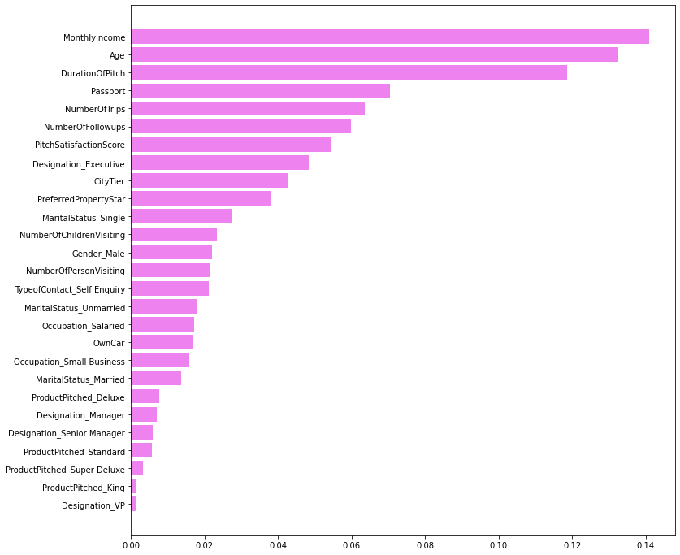

```python
feature_names = x_train.columns
importance = rForestOptimum.feature_importances_
indices = np.argsort(importance)

plt.figure(figsize=(12,12))
plt.barh(range(len(indices)), importance[indices], color='violet', align='center')
plt.yticks(range(len(indices)), [feature_names[i] for i in indices])
plt.show()
```

## Conclusion & Insights:

Since the new project will focus on wellness, it is also important to check the customer interest towards health. However, knowing that older people tend to be more concerned about health, the age target will be high and the product is flexible(okay to be expensive) with the price.

After EDA and Model Building, it became more clear that:

- The monthly income of the customer will mostly determine which tour package will be chosen.
- Age is also closely related with which package will be chosen. Note age is highly correlated with monthly income.
- Duration of the pitch, passport, and number of trips are ranked below monthly income and age.
- It seems that designation of customer limits the exposure of various packages. It should be seriously considered to advertise customers with multiple packages at a time. Or, data is not as accurate which products were advertised and which package was taken.
- Executives take tours more than any other designation. Consider setting marketing priorities.
- Consider developing abroad or driving tour since people with passport are likely to have tour.